# **Gaming and Mental Health - Causal Inference Project**

By Faatimah Majothi

## Introduction

This **`R` notebook** is a continuation of the Causal Inference portfolio project from the **Jupyter notebook** file: caus_inf_spec.ipynb

This project follows the principles of a Causal Inference workflow to investigate the relationship between digital gaming and mental health. We aim to complete a clean data analysis project that showcases an understanding of causal inference analysis along with proficiency in the use of python libraries and machine learning models.

In the previous half of the project, we covered sections A-B of the project scope:

#### **Project Scope:**

**Jupyter Notebook (Previous):**

- A: Define the problem and variables
  - Create a detailed **DAG (Directed Acyclic Graph)** using knowledge and assumptions about the **data generating process (DGP)**.
  - Identify the treatment, outcome, and confounders from the DAG.
- B: Import, explore, and preprocess the data
  - Import the dataset and perform **exploratory data analysis (EDA)**.
  - Check the available data against the assumptions of causal inference.
  - Preprocess the data as needed.

**R Notebook (Current):**

Continuing from section B, we will finish tackling the final assumption of causal inference, **Overlap (Positivity)**:

**Checking assumptions of causal inference:**

- **SUTVA (Stable Unit Treatment Value Assumption):** We assume that each individual’s outcome depends only on their own treatment status and that the treatment is applied consistently across all individuals.
- **Exchangeability/Ignorability:** We have listed potential confounders that may affect both the **treatment** (X) and the **outcome** (Y). We will extract these variables from our data and adjust for them in the analysis to help satisfy the ignorability assumption.
- **No Multicollinearity:** We will use a **heatmap** and **pair plot** to examine correlations among the confounders. High correlations may indicate multicollinearity, which can affect the stability and interpretability of our model.
- **Overlap (Positivity):** By plotting the confounders against the treatment (`gaming_hrs`) and outcome (`m_health`) variables, we will check that there is **sufficient overlap in the distribution of confounders** across treatment groups. This ensures that there are both ‘treated’ and ‘untreated’ individuals for each value of the confounders.

### Setup

```r
# Import Libraries
library(cobalt)
library(WeightIt)
library(lmtest)
library(sandwich)
library(tidyverse)
library(dplyr)

# Save current warn option to restore later
old_warn_option <- getOption('warn')

# Suppress all warnings
options(warn = -1)

# Import data
caus_df <- read.csv('caus_df.csv')
head(caus_df)
```

|  | age | income | daily_gaming_hours | weekly_sessions | years_gaming | sleep_hours | caffeine_intake | exercise_hours | stress_level | anxiety_score | depression_score | social_interaction_score | relationship_satisfaction | academic_performance | work_productivity | addiction_level | multiplayer_ratio | toxic_exposure | violent_games_ratio | mobile_gaming_ratio | night_gaming_ratio | weekend_gaming_hours | friends_gaming_count | online_friends | streaming_hours | esports_interest | microtransactions_spending | parental_supervision | loneliness_score | … |
| --- | --- | --- | --- | --- | --- | --- | --- | --- | --- | --- | --- | --- | --- | --- | --- | --- | --- | --- | --- | --- | --- | --- | --- | --- | --- | --- | --- | --- | --- | --- |
| 1 | 54 | 85406 | 1.08 | 20 | 24 | 7.72 | 5.60 | 1.91 | 4 | 3.66 | 7.82 | 8.22 | 4.02 | 72.59 | 80.78 | 0.00 | 0.71 | 0.20 | 0.10 | 0.55 | 0.10 | 10.72 | 4 | 382 | 2.09 | 5 | 735.84 | 10 | 3.93 | … |
| 2 | 39 | 52223 | 3.54 | 16 | 11 | 7.09 | 0.79 | 0.29 | 7 | 4.37 | 7.37 | 5.27 | 7.07 | 55.12 | 79.19 | 2.45 | 0.78 | 0.41 | 0.71 | 0.66 | 0.15 | 9.39 | 39 | 268 | 1.55 | 9 | 87.77 | 1 | 4.99 | … |
| 3 | 25 | 115189 | 4.94 | 10 | 0 | 7.24 | 1.67 | 0.05 | 4 | 4.21 | 2.99 | 9.08 | 6.20 | 59.96 | 52.88 | 3.76 | 0.15 | 0.15 | 0.33 | 0.39 | 0.68 | 1.24 | 40 | 95 | 2.21 | 0 | 181.21 | 10 | 5.71 | … |
| 4 | 49 | 74798 | 1.75 | 25 | 6 | 8.26 | 0.42 | 0.37 | 9 | 6.82 | 4.12 | 4.78 | 9.26 | 44.49 | 80.92 | 2.14 | 0.67 | 0.24 | 0.61 | 0.39 | 0.29 | 13.56 | 40 | 332 | 1.49 | 10 | 938.96 | 8 | 2.77 | … |
| 5 | 55 | 41451 | 1.43 | 11 | 0 | 8.00 | 0.17 | 2.41 | 9 | 7.27 | 6.25 | 4.90 | 4.69 | 64.40 | 77.80 | 0.00 | 0.44 | 0.08 | 0.31 | 0.87 | 0.76 | 14.36 | 44 | 67 | 4.98 | 7 | 73.29 | 9 | 5.17 | … |
| 6 | 35 | 22418 | 0.63 | 27 | 12 | 5.94 | 3.67 | 2.70 | 8 | 4.07 | 2.35 | 7.98 | 3.74 | 64.35 | 81.41 | 0.00 | 0.34 | 0.27 | 0.34 | 0.73 | 0.59 | 10.51 | 38 | 186 | 0.90 | 8 | 267.37 | 6 | 3.90 | … |

### **Section C:** Checking Balance and Adjustments

In the previous section from the Jupyter notebook caus_inf_spec.ipynb, we created the treatment (X) and outcome (Y) variables required for checking the **overlap** assumption of causal inference

We will now use balance plots and tables to check for **overlap**.

Before beginning, we must create a binary column that assigns `1` to rows with gaming hours **above 15% of the average** gaming hours, and `0` to rows with gaming hours **below 15% of the average**. We will also rename `gaming_hrs` to `weekly_gaming_hrs` for clarity.

```r
# Create treatment and control group column
threshold <- mean(caus_df$gaming_hrs) * 0.15
caus_df$above_15pct_avg <- as.integer(caus_df$gaming_hrs > threshold)

# Rename X variable for clarity
caus_df <- caus_df %>% rename(weekly_gaming_hrs = gaming_hrs)

# Check percentage
print(mean(caus_df$above_15pct_avg) * 100)
```

```
[1] 86.82867
```

```r
head(caus_df)
```

|  | age | income | daily_gaming_hours | weekly_sessions | years_gaming | sleep_hours | caffeine_intake | exercise_hours | stress_level | anxiety_score | depression_score | social_interaction_score | relationship_satisfaction | academic_performance | work_productivity | addiction_level | multiplayer_ratio | toxic_exposure | violent_games_ratio | mobile_gaming_ratio | night_gaming_ratio | weekend_gaming_hours | friends_gaming_count | online_friends | streaming_hours | esports_interest | microtransactions_spending | parental_supervision | loneliness_score | … |
| --- | --- | --- | --- | --- | --- | --- | --- | --- | --- | --- | --- | --- | --- | --- | --- | --- | --- | --- | --- | --- | --- | --- | --- | --- | --- | --- | --- | --- | --- | --- |
| 1 | 54 | 85406 | 1.08 | 20 | 24 | 7.72 | 5.60 | 1.91 | 4 | 3.66 | 7.82 | 8.22 | 4.02 | 72.59 | 80.78 | 0.00 | 0.71 | 0.20 | 0.10 | 0.55 | 0.10 | 10.72 | 4 | 382 | 2.09 | 5 | 735.84 | 10 | 3.93 | … |
| 2 | 39 | 52223 | 3.54 | 16 | 11 | 7.09 | 0.79 | 0.29 | 7 | 4.37 | 7.37 | 5.27 | 7.07 | 55.12 | 79.19 | 2.45 | 0.78 | 0.41 | 0.71 | 0.66 | 0.15 | 9.39 | 39 | 268 | 1.55 | 9 | 87.77 | 1 | 4.99 | … |
| 3 | 25 | 115189 | 4.94 | 10 | 0 | 7.24 | 1.67 | 0.05 | 4 | 4.21 | 2.99 | 9.08 | 6.20 | 59.96 | 52.88 | 3.76 | 0.15 | 0.15 | 0.33 | 0.39 | 0.68 | 1.24 | 40 | 95 | 2.21 | 0 | 181.21 | 10 | 5.71 | … |
| 4 | 49 | 74798 | 1.75 | 25 | 6 | 8.26 | 0.42 | 0.37 | 9 | 6.82 | 4.12 | 4.78 | 9.26 | 44.49 | 80.92 | 2.14 | 0.67 | 0.24 | 0.61 | 0.39 | 0.29 | 13.56 | 40 | 332 | 1.49 | 10 | 938.96 | 8 | 2.77 | … |
| 5 | 55 | 41451 | 1.43 | 11 | 0 | 8.00 | 0.17 | 2.41 | 9 | 7.27 | 6.25 | 4.90 | 4.69 | 64.40 | 77.80 | 0.00 | 0.44 | 0.08 | 0.31 | 0.87 | 0.76 | 14.36 | 44 | 67 | 4.98 | 7 | 73.29 | 9 | 5.17 | … |
| 6 | 35 | 22418 | 0.63 | 27 | 12 | 5.94 | 3.67 | 2.70 | 8 | 4.07 | 2.35 | 7.98 | 3.74 | 64.35 | 81.41 | 0.00 | 0.34 | 0.27 | 0.34 | 0.73 | 0.59 | 10.51 | 38 | 186 | 0.90 | 8 | 267.37 | 6 | 3.90 | … |

Next, we will plot balance plots of some of the columns to check the **overlap**.

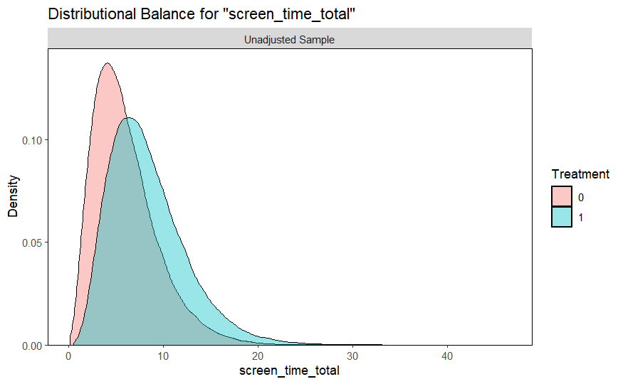

```r
# Plot balance plots
bal.plot(x = above_15pct_avg ~ screen_time_total, data = caus_df, var.name = 'screen_time_total')
```

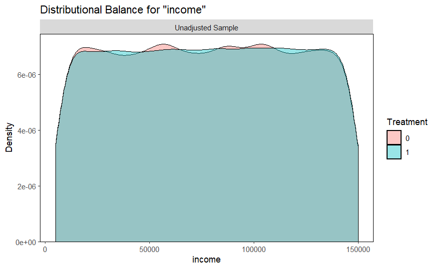

```r
bal.plot(x = above_15pct_avg ~ income, data = caus_df, var.name = 'income')
```

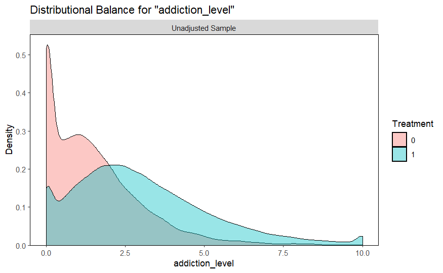

```r
bal.plot(x = above_15pct_avg ~ addiction_level, data = caus_df, var.name = 'addiction_level')
```

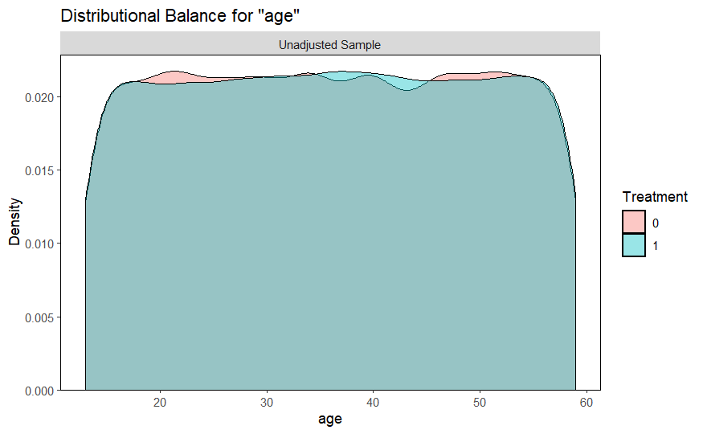

```r
bal.plot(x = above_15pct_avg ~ age, data = caus_df, var.name = 'age')
```

Out of the covariates plotted, `addiction_level` has the **least overlap** across treatment and control groups. This may bias the causal estimates we calculate further down the line.

We will now plot a **numerical balance table** to investigate the overlap between treatment and control groups further. For efficiency, we will **not** be plotting all of the covariates in this table.

We will keep the following in mind when considering the values in the balance plot:

- **Standardized Mean Difference (SMD):** Values close to 0 (usually within ±0.1) mean good balance between groups for that variable.
- **Variance Ratio:** Ratios between 0.5 and 2 are generally considered acceptable.

```r
# Create balance table
bal.tab(
  above_15pct_avg ~ age + income + daily_gaming_hours +
    years_gaming + sleep_hours + caffeine_intake + exercise_hours +
    stress_level + anxiety_score + depression_score +
    social_interaction_score + academic_performance +
    work_productivity + addiction_level +
    multiplayer_ratio + toxic_exposure + violent_games_ratio +
    night_gaming_ratio + weekend_gaming_hours +
    friends_gaming_count + online_friends + streaming_hours +
    microtransactions_spending + screen_time_total + eye_strain_score +
    back_pain_score + weekly_gaming_hrs + z_stress +
    z_anxiety + z_depression + z_loneliness + z_aggression +
    z_happiness + m_health,
  data = caus_df,
  binary = 'std',
  disp.v.ratio = TRUE
)
```

```
Balance Measures
                              Type Diff.Un V.Ratio.Un
age                        Contin.  0.0040     1.0007
income                     Contin.  0.0053     1.0008
daily_gaming_hours         Contin.  0.9779     2.4053
years_gaming               Contin. -0.0115     1.0081
sleep_hours                Contin. -0.0084     1.0019
caffeine_intake            Contin.  0.0053     1.0158
exercise_hours             Contin. -0.0083     0.9901
stress_level               Contin.  0.0084     1.0059
anxiety_score              Contin. -0.0112     1.0231
depression_score           Contin.  0.0033     0.9922
social_interaction_score   Contin. -0.0146     1.0060
academic_performance       Contin. -0.0054     1.0061
work_productivity          Contin. -0.0002     0.9853
addiction_level            Contin.  0.8333     2.0754
multiplayer_ratio          Contin. -0.0028     0.9896
toxic_exposure             Contin.  0.0021     1.0190
violent_games_ratio        Contin.  0.0030     1.0166
night_gaming_ratio         Contin. -0.0109     0.9896
weekend_gaming_hours       Contin. -0.0009     1.0131
friends_gaming_count       Contin. -0.0162     1.0023
online_friends             Contin.  0.0096     0.9939
streaming_hours            Contin. -0.0096     0.9760
microtransactions_spending Contin.  0.0056     0.9932
screen_time_total          Contin.  0.6270     1.4078
eye_strain_score           Contin.  0.0035     0.9888
back_pain_score            Contin. -0.0066     1.0055
weekly_gaming_hrs          Contin.  1.5117   603.3488
z_stress                   Contin.  0.0084     1.0059
z_anxiety                  Contin. -0.0112     1.0231
z_depression               Contin.  0.0033     0.9922
z_loneliness               Contin.  0.0096     1.0226
z_aggression               Contin. -0.0027     0.9908
z_happiness                Contin.  0.0053     1.0038
m_health                   Contin. -0.0009     1.0030

Sample sizes
    Control Treated
All   19757  130243
```

**Note: Higher values are expected for the `daily_gaming_hours` and `weekly_gaming_hrs` column as the latter column was calculated using data from the former.**

The majority of the values in the numerical balance table have balanced **SMD** and are within the **acceptable variance ratio**, apart from two. In the previous EDA section of the analysis, our pair plot revealed **possible multicollinearity** between `addiction_level` and `screen_time_total`. These two columns are unbalanced and may confound our results if they are not adjusted for.

This will **reduce multicollinearity** while keeping the information from both variables.

```r
# Perform PCA
pca_vars <- caus_df[, c('addiction_level', 'screen_time_total')]
pca_vars_scaled <- scale(pca_vars)
pca_result <- prcomp(pca_vars_scaled)
caus_df$pca_addiction_screen <- pca_result$x[, 1] # Extract principal component

# Clean and adjust dataframe
model_df <- caus_df %>% select(-addiction_level, -screen_time_total, -stress_level, -aggression_score, -anxiety_score, -happiness_score, -depression_score, -loneliness_score, -z_stress, -z_anxiety, -z_depression, -z_loneliness, -z_aggression, -z_happiness, -daily_gaming_hours, -weekly_sessions)
print(colnames(model_df))
```

```
 [1] "age"                        "income"                     "years_gaming"               "sleep_hours"
 [5] "caffeine_intake"            "exercise_hours"             "social_interaction_score"   "relationship_satisfaction"
 [9] "academic_performance"       "work_productivity"          "multiplayer_ratio"          "toxic_exposure"
[13] "violent_games_ratio"        "mobile_gaming_ratio"        "night_gaming_ratio"         "weekend_gaming_hours"
[17] "friends_gaming_count"       "online_friends"             "streaming_hours"            "esports_interest"
[21] "microtransactions_spending" "parental_supervision"       "bmi"                        "eye_strain_score"
[25] "back_pain_score"            "competitive_rank"           "weekly_gaming_hrs"          "m_health"
[29] "above_15pct_avg"            "pca_addiction_screen"
```

```r
# Create adjusted balance table
bal.tab(
  above_15pct_avg ~ age + income +
    daily_gaming_hours + years_gaming + sleep_hours +
    caffeine_intake + exercise_hours +
    stress_level + anxiety_score + depression_score +
    social_interaction_score + academic_performance +
    work_productivity + multiplayer_ratio +
    toxic_exposure + violent_games_ratio +
    night_gaming_ratio + weekend_gaming_hours +
    friends_gaming_count + online_friends + streaming_hours +
    microtransactions_spending + eye_strain_score +
    back_pain_score + weekly_gaming_hrs + z_stress +
    z_anxiety + z_depression + z_loneliness +
    z_aggression + z_happiness + m_health,
  data = caus_df,
  binary = 'std',
  disp.v.ratio = TRUE
)
```

```
Balance Measures
                              Type Diff.Un V.Ratio.Un
age                        Contin.  0.0040     1.0007
income                     Contin.  0.0053     1.0008
daily_gaming_hours         Contin.  0.9779     2.4053
years_gaming               Contin. -0.0115     1.0081
sleep_hours                Contin. -0.0084     1.0019
caffeine_intake            Contin.  0.0053     1.0158
exercise_hours             Contin. -0.0083     0.9901
stress_level               Contin.  0.0084     1.0059
anxiety_score              Contin. -0.0112     1.0231
depression_score           Contin.  0.0033     0.9922
social_interaction_score   Contin. -0.0146     1.0060
academic_performance       Contin. -0.0054     1.0061
work_productivity          Contin. -0.0002     0.9853
multiplayer_ratio          Contin. -0.0028     0.9896
toxic_exposure             Contin.  0.0021     1.0190
violent_games_ratio        Contin.  0.0030     1.0166
night_gaming_ratio         Contin. -0.0109     0.9896
weekend_gaming_hours       Contin. -0.0009     1.0131
friends_gaming_count       Contin. -0.0162     1.0023
online_friends             Contin.  0.0096     0.9939
streaming_hours            Contin. -0.0096     0.9760
microtransactions_spending Contin.  0.0056     0.9932
eye_strain_score           Contin.  0.0035     0.9888
back_pain_score            Contin. -0.0066     1.0055
weekly_gaming_hrs          Contin.  1.5117   603.3488
z_stress                   Contin.  0.0084     1.0059
z_anxiety                  Contin. -0.0112     1.0231
z_depression               Contin.  0.0033     0.9922
z_loneliness               Contin.  0.0096     1.0226
z_aggression               Contin. -0.0027     0.9908
z_happiness                Contin.  0.0053     1.0038
m_health                   Contin. -0.0009     1.0030

Sample sizes
    Control Treated
All   19757  130243
```

### **Section D:** Estimating and Validating Causal Effect

We have chosen **ATE (Average Treatment Effect)** as the causal estimand for this analysis. The ATE represents the **average difference in the outcome** (overall mental health,`m_health`) between individuals who have higher gaming hours (our treatment group) and those who have lower gaming hours (our control group), after adjusting for confounders. By measuring this estimand, we aim to investigate, on average, how increased gaming hours affect mental health score in the population.

First, we will fit our model to estimate the causal effect, ensuring we use the adjusted and preprocessed dataframe `model_df`.

```r
# Get covariates list to paste into model
vars <- colnames(model_df)
cat(paste0("", vars, "", collapse = ' + '))
```

```
age + income + years_gaming + sleep_hours + caffeine_intake + exercise_hours + social_interaction_score + relationship_satisfaction + academic_performance + work_productivity + multiplayer_ratio + toxic_exposure + violent_games_ratio + mobile_gaming_ratio + night_gaming_ratio + weekend_gaming_hours …
```

```r
# Fit outcome regression model
mHealth_mod <- glm(
  formula = m_health ~ above_15pct_avg + age + income + years_gaming + sleep_hours + caffeine_intake + exercise_hours + social_interaction_score + relationship_satisfaction + academic_performance + work_productivity + multiplayer_ratio + toxic_exposure + violent_games_ratio + mobile_gaming_ratio + night_gaming_ratio + weekend_gaming_hours + friends_gaming_count + online_friends + streaming_hours + esports_interest + microtransactions_spending + parental_supervision + bmi + eye_strain_score + back_pain_score + competitive_rank + weekly_gaming_hrs + pca_addiction_screen,
  data = model_df
)
```

Next, we will estimate the regression coefficients for our model with robust standard errors.

```r
# Estimate the regression coefficients with robust standard errors
coeftest(mHealth_mod, vcov. = vcovHC)
```

```
z test of coefficients:

                              Estimate  Std. Error z value Pr(>|z|)
(Intercept)                -1.8141e-02  1.4773e-02 -1.2280  0.21946
above_15pct_avg            -2.0704e-03  3.3441e-03 -0.6191  0.53584
age                         1.3720e-04  7.7976e-05  1.7595  0.07849 .
income                      4.9479e-09  2.5221e-08  0.1962  0.84447
years_gaming                2.5246e-04  1.4627e-04  1.7260  0.08436 .
sleep_hours                 1.4634e-04  6.9735e-04  0.2099  0.83378
caffeine_intake            -6.1413e-04  5.3203e-04 -1.1543  0.24837
exercise_hours             -5.7631e-04  5.2468e-04 -1.0984  0.27203
social_interaction_score   -5.0807e-04  5.3959e-04 -0.9416  0.34640
relationship_satisfaction   1.1767e-04  5.4158e-04  0.2173  0.82799
academic_performance        4.2779e-05  7.1626e-05  0.5973  0.55034
work_productivity           4.6884e-05  7.1912e-05  0.6520  0.51442
multiplayer_ratio           4.3578e-03  4.7025e-03  0.9267  0.35409
toxic_exposure             -8.1542e-03  6.6146e-03 -1.2328  0.21767
violent_games_ratio         4.1410e-03  5.2488e-03  0.7889  0.43015
mobile_gaming_ratio        -5.1038e-03  4.7158e-03 -1.0823  0.27913
night_gaming_ratio         -2.8217e-03  4.7267e-03 -0.5970  0.55052
weekend_gaming_hours        4.3933e-04  2.4698e-04  1.7788  0.07528 .
friends_gaming_count        6.8656e-06  7.2783e-05  0.0943  0.92485
online_friends             -4.1727e-06  7.3069e-06 -0.5711  0.56795
streaming_hours             1.3056e-03  7.4153e-04  1.7607  0.07828 .
esports_interest            3.1953e-04  3.3345e-04  0.9583  0.33793
microtransactions_spending -2.9588e-06  2.1170e-06 -1.3976  0.16222
parental_supervision        3.9920e-04  3.3435e-04  1.1940  0.23249
bmi                         2.4340e-04  2.6473e-04  0.9194  0.35787
eye_strain_score           -4.7251e-05  5.3047e-04 -0.0891  0.92902
back_pain_score            -7.2400e-04  5.3788e-04 -1.3460  0.17829
competitive_rank           -5.0184e-06  3.6489e-05 -0.1375  0.89061
weekly_gaming_hrs           3.1347e-05  1.7930e-05  1.7483  0.08041 .
pca_addiction_screen       -9.6904e-04  1.0662e-03 -0.9089  0.36343
---
Signif. codes:  0 ‘***’ 0.001 ‘**’ 0.01 ‘*’ 0.05 ‘.’ 0.1 ‘ ’ 1
```

The results can be broken down as follows:

- The coefficient for `above_15pct_avg`, which represents our average treatment effect (ATE), is **not statistically significant**, as it has a p-value of 0.54.
- The value of the causal estimate (-0.00207), indicates that on average, having above 15% of the average weekly gaming hours is associated with a **decrease of approximately 0.002 units** in mental health score compared to being below the threshold, after adjusting for other variables.
- In a nutshell, the results provide **no strong evidence** to support the hypothesis that being above the 15% threshold has a causal effect on mental health score. Other variables, such as `age` and `years_gaming` show **weak associations** but still **do not meet the 0.05 significance threshold**.

Lastly, we will check the robustness of the model by checking the residuals with a scatterplot.

```r
# Get residuals and plot
residuals <- resid(mHealth_mod)
fitted <- fitted(mHealth_mod)

plot(fitted, residuals,
     xlab = 'Fitted Values',
     ylab = 'Residuals',
     main = 'Residuals vs Fitted')
abline(h = 0, col = 'red')
```

[output not shown]

### **Conclusion:**

Our causal estimate of the ATE found that most of our confounders, including our main predictor `above_15pct_avg`, **do not have a statistically significant effect on the outcome `m_health`** variable, as their **p-values are above the statistical significance threshold of 0.05**. However, a few of the coefficients, such as `age`, `years_gaming`, `weekend_gaming_hours`, `streaming_hours`, and **most importantly, `weekly_gaming_hours`,** have p-values closer to 0.05, which suggests that they may have a weak association with `m_health`.

This result can somewhat be **expected from synthetic data**, such as that which was used in this project, as the distributions are unnaturally even. Reproducing this causal estimation workflow with **real data** may produce ‘better’ **more significant results** that are indicative of a causal relationship between mental health and gaming hours.

Overall, based on the data used, the results of the model do not provide strong evidence that any single variable in the model is a significant predictor of mental health.

**Further development possibilities:**

- Use real-life data rather than synthetic.
- Attempt weighting covariates.
- Create and compare weighted models.
- Calculate a different causal estimand.

#### **Links:**

- Codecademy course:Data Scientist: Inference Specialist Career Path
- Github Repository: Causal-Inference-Analysis Repo.